← All chapters Source: `ch08_image_processing_applications.ipynb`

Get the notebook ↓ Download .ipynb [▶ Open in Colab](https://colab.research.google.com/github/shammun/seaice-py/blob/main/notebooks/ch08_image_processing_applications_colab.ipynb)

# Chapter 8 — Sea Ice Image Processing Applications

*Sea Ice Image Processing with MATLAB* (Q. Zhang & R. Skjetne, CRC Press 2018), Chapter 8, pp. 175–194 — Python port `seaice-py`, notebook `notebooks/ch08_image_processing_applications.ipynb`.

Chapters 2–7 built a pipeline; Chapter 8 is what the pipeline is **for**. Three field campaigns, three platforms, three questions:

| section | platform | question | can we reproduce it? |
| --- | --- | --- | --- |
| **8.1** (pp. 176–181) | a 4-lens camera on the icebreaker **IB *Frej*** (OATRC'15), 1 frame / 10 s | *ice concentration* in real time: Otsu vs k-means | **method only** — no code and no images ship (open item **O1**) |
| **8.2** (pp. 181–189) | a **CryoWing UAV** over Ny-Ålesund | *characterise* a real ice field so that a DEM simulator can be initialised from it | **pipeline yes, printed counts no** (open item **O2**) |
| **8.3** (pp. 189–194) | a **helicopter** off IB *Oden* (OATRC'15) | the *floe size distribution* and its power-law exponent | **yes, bit-exactly** — the authors ship their own data |
| **App. B** (pp. 221–225) | — | the MATLAB data structure all of it is stored in | **yes** — reproduced field by field |

**Sections covered** (one notebook section each, in book order): 8.1.2 Methods (Otsu / k-means, Figs. 8.4–8.6) · 8.2 Ice-field characterization (Figs. 8.8–8.11) · 8.2.1 Sea ice numerical modeling (Figs. 8.12–8.15) · 8.3 Floe size statistic (**Eq. 8.1** MCD, **Eqs. 8.2/8.3** cumulative FSD and power law, Figs. 8.19–8.21) · Appendix B — the `IceImage` data structure · the **MATLAB traps** this chapter turns up · parameter play · summary.

**MATLAB files this notebook replaces** (9 `.m` files: 5 in `MATLAB_ROOT/ch8/MCD/`, 4 deferred here from `ch{6,7}/Sea_Ice_Floe_Identification/` — those four are **byte-identical** in ch6 and ch7). Parity from `reports/ch08_verification.md`; the reference engine is MATLAB R2025a running the original code:

| MATLAB file | Python (imported below) | Parity |
| --- | --- | --- |
| `MCD/main_WL_new.m` (the §8.3 driver) | `seaice.ch08_applications.mcd_analysis` | **exact** — every array, max \|Δ\| = **0.0** |
| `MCD/plot_color_bar_and_floe.m` (Figs. 8.19/8.20) | `ch08_applications.plot_color_bar_and_floe` | **exact** (arrays): the 627×1114×3 painted map is **byte-identical**; the figures are display |
| `MCD/fitting_iceFloes_distribution.m` (Fig. 8.21) | `ch08_applications.cumulative_fsd_powerlaw` | **near** — α agrees with MATLAB to 10 s.f.; the file **as shipped is a syntax error** (erratum E1) |
| `MCD/PowerLaw_fitting_method_and_plotting.m` (orphan — no caller anywhere) | `ch08_applications.power_law_fit` | near |
| `MCD/three_fitting_method_and_plotting.m` (call site commented out) | `ch08_applications.three_distribution_fits` | near — the truncated power law's 3rd parameter is *unidentifiable* (deviation D2) |
| `SIFI/sea_ice_model.m` (§8.2.1, Figs. 8.12/8.13) | `ch08_applications.sea_ice_model` | `Area`/`Center`/`Perimeter`/`Radius`/`Intersect` **exact**; `Vertices` **near** (hull vertex *order*) |
| `SIFI/SeaIce_Image_Structure.m` (Appendix B) | `core.icestruct.*`, `ch08_applications.sea_ice_image_structure` | **exact** — all 12 numeric `Field` members and all 51 `FSD` triplets |
| `SIFI/color_hist.m` (Figs. 8.11/8.14) | `ch08_applications.color_hist` | **exact** |
| `SIFI/color_hist_comparison.m` (Fig. 8.15) | `ch08_applications.color_hist_comparison` | **exact** |
| *(no `.m` — §8.1's two methods are text only)* | `ch08_applications.shipborne_ice_concentration` | method **exact** (ch03's Otsu / the authors' own k-means); **results `unverified`** |
| *(no `.m` — §8.2's "Algorithms 3, 4 and 5 are carried out directly")* | `ch08_applications.sea_ice_field` | **unverified** (it *is* ch07's chain, verified there) |

> **What this notebook will and will not claim.** §8.3 is the most solidly verified chain in the book: it is reproduced **bit-exactly** against MATLAB *and* against the authors' own shipped `MCD_results.mat`, down to α = **1.3704**. §8.2 is honest but incomplete — our pipeline finds **433 floes / 290 brash**, the book prints **498 / 201**, the authors' parameter set appears nowhere in the book, and **no parameter search was performed** to close the gap (open item O2). §8.1 has neither code nor data: it is demonstrated on a *synthetic* frame, and **every number the book prints for §8.1 stays unverified** (open item O1). The rectification that precedes §8.1 is Appendix A.1.2 and belongs to **Chapter 10** — no second rectifier is written here.

## Setup (Google Colab or local Jupyter)

Run the two cells below first. On **Colab** the first cell mounts your Google Drive and moves into `MyDrive/Sea_Ice_Colab` — the folder where your private copy of the book's data lives (`data/book/ch08/MCD/*.mat`, and `data/book/ch07/.../sea_ice_test.jpg`) and where downloads are cached between sessions; readers without Drive get a temporary `/content/Sea_Ice_Colab`. The second cell clones (or updates) the public repository `seaice-py` there and installs its requirements. **Locally** both cells are no-ops that move to the repository root. No GPU is needed.

> ⚠️ **If you run this with your own copy of the book's data, do not use *File → Save a copy in GitHub*.** That saves the cell outputs — figures rendered from copyrighted book material — into the public repository. Save to Drive instead (*File → Save a copy in Drive*). The repository's `_colab.ipynb` is always regenerated with outputs stripped.

```python
import os
try:
    from google.colab import drive; drive.mount('/content/drive')
    os.makedirs('/content/drive/MyDrive/Sea_Ice_Colab', exist_ok=True)
    DRIVE_OK = True
except Exception:
    DRIVE_OK = False
    if os.path.isdir('/content'):                                   # Colab without a Google Drive
        print("No Google Drive — using /content/Sea_Ice_Colab")
        os.makedirs('/content/Sea_Ice_Colab', exist_ok=True); os.chdir('/content/Sea_Ice_Colab')
    else:                                                           # local Jupyter: go to the repository root
        import pathlib
        here = pathlib.Path.cwd().resolve()
        for cand in (here, *here.parents):
            if (cand / "seaice").is_dir() and (cand / "data").is_dir():
                os.chdir(cand); break
    print(os.getcwd())
if DRIVE_OK:                                                        # the chdir to Drive only runs after a successful mount
    os.chdir('/content/drive/MyDrive/Sea_Ice_Colab')
    print(os.getcwd())
```

```
C:\Users\sislam27\Work\Climate Dynamics PHD\Sea Ice Image Processing with MATLAB
```

```python
import os, sys
IN_COLAB = os.path.isdir('/content') and ('google.colab' in sys.modules or os.getcwd().startswith('/content'))
if IN_COLAB:
    if os.path.exists('seaice-py'):
        !git -C seaice-py pull
    else:
        !git clone --depth 1 https://github.com/shammun/seaice-py.git
    !pip install -q -r seaice-py/requirements-colab.txt
    sys.path.insert(0, "seaice-py")
else:
    sys.path.insert(0, os.getcwd())                                 # local: the repository root from the cell above
print("seaice imported from:", "seaice-py/ (Colab clone)" if IN_COLAB else os.getcwd())
```

```
seaice imported from: C:\Users\sislam27\Work\Climate Dynamics PHD\Sea Ice Image Processing with MATLAB
```

## Data

Chapter 8 needs two things, and they behave differently.

1. **The §8.2 image.** Figure 8.8 is *the same photograph* as Chapter 6/7's `sea_ice_test.jpg`, printed transposed and inverted (the analysis correlated the printed bitmap at **NCC +0.982** with the inverted transpose of the shipped file, and +0.974 with the Fig. 7.22 bitmap). `seaice.core.io.load_image` finds **your private copy** first — `data/book/ch08/…`, then `data/book/ch07/…`, in the current folder, in the repository or in Drive — and otherwise downloads a **public-domain NASA MODIS scene of the same 394 × 1038 size** into `data/online/ch08/`, so the notebook runs either way.
2. **The §8.3 data.** `ch8/MCD/` ships two `.mat` files: `IceImage_290915_2_jpg.0000179.mat` (the Appendix-B structure of the helicopter frame — **2888 floes, 3452 brash pieces**) and `MCD_results.mat` (the authors' own saved `Raw_MCD`, 1 × 2888 — a **gold** reference). They come with the book's MATLAB archive, are **not** in the public repository, and there is no public-domain substitute for a *data structure*. When they are missing §8.3 below does **not** fail: it runs the identical chain on the field **we** identify in §8.2, prints `SKIP (book data absent)` wherever a book number would go, and says so on every figure.

```python
from seaice.core.io import data_roots, load_image

# Figure 8.8 = ch6/ch7's `sea_ice_test.jpg`.  Private copy under ch08, then under ch07 (where the book's own
# archive puts it), then the registered public-domain substitute.  No image path is hard-coded anywhere else.
I = SOURCE = None
for _chapter in ("ch08", "ch07"):
    try:
        I, SOURCE = load_image(_chapter, "sea_ice_test.jpg", allow_fallback=False)
        break
    except FileNotFoundError:
        pass
if I is None:
    I, SOURCE = load_image("ch08", "sea_ice_test.jpg")               # public-domain substitute

FROM_BOOK = SOURCE.startswith("book")
book = (lambda s: f"  (book: {s})") if FROM_BOOK else (lambda s: "")        # book values only for the book image
if not FROM_BOOK:
    print("Running on a public-domain substitute image; figures show the same operations, "
          "but values quoted in the book only hold for the book's own image.")
print(f"Figure 8.8 (= sea_ice_test.jpg): {I.shape} {I.dtype}   [{SOURCE}]")
print(f"the book prints it transposed, i.e. {I.shape[1]} x {I.shape[0]}" + book("Fig. 8.8, p. 184"))
if I.max() == I.min():
    print("WARNING: the image is constant — the download most likely failed; re-run this cell.")
```

```
Data source: public-domain substitute (NASA) — C:/Users/sislam27/Work/Climate Dynamics PHD/Sea Ice Image Processing with MATLAB/data/online/ch08/nasa_modis_terra_beaufort_floes_394x1038_2019-07-25.jpg
  (NASA Worldview Snapshots, MODIS/Terra corrected reflectance (true colour), Beaufort Sea pack ice, 25 July 2019, 73.60-75.60 N 151.20-150.44 W; NASA imagery is in the public domain (https://www.earthdata.nasa.gov/engage/open-data-services-and-software/data-and-information-policy))
Running on a public-domain substitute image; figures show the same operations, but values quoted in the book only hold for the book's own image.
Figure 8.8 (= sea_ice_test.jpg): (1038, 394, 3) uint8   [public-domain substitute (NASA)]
the book prints it transposed, i.e. 394 x 1038
```

```python
from pathlib import Path

def find_book_mat(name: str):
    """First match of `name` under any `data/book/ch08/` root, or None (the notebook then degrades gracefully).

    The roots are exactly the ones `load_image` searches: the current folder, the repository, and
    `MyDrive/Sea_Ice_Colab` on Colab.  Sub-folders are walked, so the book's own `MCD/` layout works verbatim.
    """
    for root in data_roots():
        folder = root / "data" / "book" / "ch08"
        if folder.is_dir():
            for hit in sorted(folder.rglob(name)):
                return hit
    return None

MAT_ICEIMAGE = find_book_mat("IceImage_290915_2_jpg.0000179.mat")     # main_WL_new.m line 7
MAT_MCD      = find_book_mat("MCD_results.mat")                       # fitting_iceFloes_distribution.m line 7
HAVE_BOOK_MAT = MAT_ICEIMAGE is not None
mcd_book = (lambda s: f"  (book: {s})") if HAVE_BOOK_MAT else (lambda s: "")

if HAVE_BOOK_MAT:
    print(f"section 8.3 data: {MAT_ICEIMAGE.as_posix()}")
    print(f"                  {MAT_MCD.as_posix() if MAT_MCD else 'MCD_results.mat NOT found (optional)'}")
else:
    print("SKIP (book data absent): the two section 8.3 .mat files were not found.\n"
          "  They ship inside the book's MATLAB archive as ch8/MCD/IceImage_290915_2_jpg.0000179.mat and\n"
          "  ch8/MCD/MCD_results.mat; they are not redistributable, so the public repository does not carry\n"
          "  them, and no public-domain substitute for a data STRUCTURE exists.\n"
          "  If you own the book: copy that folder to  <this folder>/data/book/ch08/MCD/  (on Colab:\n"
          "  MyDrive/Sea_Ice_Colab/data/book/ch08/MCD/) and re-run this cell.\n"
          "  Otherwise section 8.3 runs the SAME chain on the ice field identified in section 8.2, and every\n"
          "  number it prints is ours, not the book's.")
```

```
SKIP (book data absent): the two section 8.3 .mat files were not found.
  They ship inside the book's MATLAB archive as ch8/MCD/IceImage_290915_2_jpg.0000179.mat and
  ch8/MCD/MCD_results.mat; they are not redistributable, so the public repository does not carry
  them, and no public-domain substitute for a data STRUCTURE exists.
  If you own the book: copy that folder to  <this folder>/data/book/ch08/MCD/  (on Colab:
  MyDrive/Sea_Ice_Colab/data/book/ch08/MCD/) and re-run this cell.
  Otherwise section 8.3 runs the SAME chain on the ice field identified in section 8.2, and every
  number it prints is ours, not the book's.
```

## Imports

```python
import time

import numpy as np
import seaice.core                                        # imports seaice.core.plotting (sets the Agg backend)
from seaice.ch06_gvf_snake import BOOK_PARAMS
from seaice.ch07_ice_type import IcePiece, colorbar_area_ticks, size_color
from seaice.ch08_applications import (CIRCLE_ANGLES, COLOR_LIMIT_N, LENGTH_OVER_PIXEL, MCD_X_BIN,
                                      color_hist, color_hist_comparison, cumulative_fsd_powerlaw,
                                      iceimage_to_pieces, matlab_colon, mcd_analysis,
                                      plot_color_bar_and_floe, sea_ice_field, sea_ice_image_structure,
                                      sea_ice_model, shipborne_ice_concentration, three_distribution_fits)
from seaice.ch08_applications import _matlab_c1c2          # internal: the c(1), c(2) read of deviation D4
from seaice.core.histogram import hist as matlab_hist
from seaice.core.icestruct import load_iceimage_mat, overlap_graph, save_iceimage_mat
from seaice.core.plotting import imshow_matlab, label2rgb, matlab_jet, mcd_colorbar, size_colorbar
from seaice.core.stats import cumulative_size_distribution, mean_caliper_diameter
from seaice.core.synth import synthetic_floe_field

%matplotlib inline
import matplotlib.pyplot as plt
plt.rcParams["figure.dpi"] = 100

P = BOOK_PARAMS["sea_ice_demo"]          # ch6/ch7's shipped parameter block — section 8.2 uses it unchanged
SCALE = 1

def T(img):
    """Display transpose only: the book prints this scene as Fig. 8.8 (= Fig. 7.22), 394 rows x 1038 columns."""
    return np.swapaxes(img, 0, 1) if img.ndim == 3 else img.T

print(f"length_over_Pixel = {LENGTH_OVER_PIXEL} m/px, color_limit_N = {COLOR_LIMIT_N}, "
      f"x_bin = 1:100 ({MCD_X_BIN.size} centres)")
print("ch6/ch7 parameter block:", ", ".join(f"{k} = {v}" for k, v in P.items()))
```

```
length_over_Pixel = 1.1794 m/px, color_limit_N = 30, x_bin = 1:100 (100 centres)
ch6/ch7 parameter block: kms0 = 3, Ra_min = 10, Ra = 2500, Rc = 0.9, Rl = 2, se_radius = 3, Num = 500, iter = 100, se_th = 50, min_floe = 40, min_brash = 1, sigma = 0, GradientOn = 1, GVFOn = 1, mu = 0.1, alpha = 0.05, beta = 0.0, gamma = 1.0, kappa = 0.5, Dmin = 0.0, Dmax = 1.0, timer = 1
```

## 8.1 A shipborne camera system to acquire sea ice concentration at engineering scale (pp. 176–181)

During expedition **OATRC'15** (NTNU + the Swedish Polar Research Secretariat) a four-lens "Ice Concentration" camera covering roughly 180° was mounted on IB *Frej* and triggered **once every 10 s**. The camera looks obliquely at the sea, so a raw frame is perspective-distorted — many pixels per square metre near the ship, few far away — and a pixel count would be meaningless. The frame is therefore **rectified** first, with the linear four-corner method of **Appendix A.1.2**: the image coordinates of the four corners of a rectangle of known physical size (a checkerboard) give a transformation matrix. Because the checkerboard sits **5.90 m** above the sea plane and the camera **25.50 m**, the rectified plane has to be projected a second time onto the sea plane; the two white triangles outside the lens footprint are cropped, leaving a region of about **400 m × 100 m**.

Ice concentration is then simply *ice pixels / total pixels*, and §8.1.2 extracts the ice pixels **two ways at once**: the global **Otsu** threshold of §3.1 (white = ice), and **k-means with k = 3** of §3.2, whose clusters are read as water (black) / **wet ice** (grey: rubble, young ice, melt ponds) / dry ice (white) — with the grey cluster counted as ice. That is why the k-means series of Fig. 8.5 sits systematically *above* the Otsu series over the six hours of 26 September 2015, and it explains both discrepancy events of Fig. 8.6: **Event #1**, dark young ice that Otsu calls water, and **Event #2**, adverse illumination that pushes ice below Otsu's threshold. "If we choose two clusters for the k-means method (k = 2), then this method is approximately reduced to the Otsu thresholding method" (p. 179).

> **No MATLAB file and no images ship for §8.1.** Figures 8.1–8.6 are credited to Lu, Zhang, Lubbad, Løset & Skjetne (OTC Arctic Technology Conference 2016), and neither the photographs nor the ~2160-frame time series are anywhere in the book's code archive. So this section demonstrates the **method** on a *synthetic* frame, and **every number the book prints for §8.1 is `unverified`** (open item O1) — none of them is reproduced here. The rectification is **not** implemented here either: it is Appendix A.1.2 and belongs to Chapter 10, which owns the rectifier. Writing a second one in Chapter 8 would be exactly the kind of silent duplication the project forbids.

> The two *methods*, on the other hand, are already verified: `graythresh`/`im2bw` are `exact` from ch03, and `shipborne_ice_concentration(..., impl='authors')` — the **default** — routes k-means through `core.clustering.kmeans_gray`, a line-by-line port of the authors' own `MATLAB_ROOT/ch3/kmeans.m`, which is **deterministic** (equal-division initialisation, histogram-weighted centroids, exact `mu == oldmu` stop) and `exact`. The alternative `impl='lloyd'` is a generic seeded k-means++/Lloyd routine and is only `approx`.

```
synthetic layers (ground truth): dry ice 32.62 %, wet ice 4.23 %, water 63.14 %
```

```
Otsu          : level = 0.543137 (138.5/255), IC = 32.62 % -> it finds the dry ice only (32.62 % is the truth for dry ice alone)
k-means (k = 3): centres [12.04, 75.14, 209.99], ice = the 2 brightest clusters, IC = 36.86 %
k-means - Otsu = +4.23 pp — the SIGN the book reports for Figure 8.5 (p. 180): the grey 'wet ice' cluster counts as ice, so k-means always reads higher.
These numbers are OURS, measured on a synthetic frame. The book's 6-hour series, Event #1 and Event #2 are `unverified` (open item O1): their imagery does not ship.
```

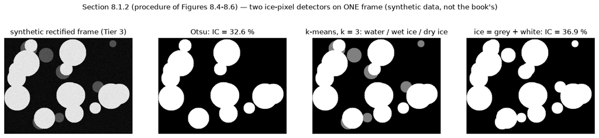

```python
# A synthetic three-level frame, the way section 8.1.2 reads the k-means clusters: water / "wet ice" (grey
# rubble, young ice, melt ponds) / dry ice.  Tier 3 — synthetic and seeded.  NOT the book's imagery.
rng = np.random.default_rng(0)
dry = synthetic_floe_field((300, 400), n_floes=14, seed=0, radius=(18, 45)) > 0
wet = (synthetic_floe_field((300, 400), n_floes=10, seed=1, radius=(10, 26)) > 0) & ~dry
frame = np.full((300, 400), 12.0)
frame[wet] = 75.0                       # deliberately BELOW the Otsu threshold: the Event #1 situation, p. 181
frame[dry] = 210.0
frame = np.clip(np.floor(frame + rng.normal(0.0, 6.0, frame.shape) + 0.5), 0, 255).astype(np.uint8)
print(f"synthetic layers (ground truth): dry ice {100 * dry.mean():.2f} %, wet ice {100 * wet.mean():.2f} %, "
      f"water {100 * (~dry & ~wet).mean():.2f} %")

o  = shipborne_ice_concentration(frame, "otsu")                                   # section 3.1
k3 = shipborne_ice_concentration(frame, "kmeans", k=3)                            # section 3.2, ice = grey + white
print(f"Otsu          : level = {o.level:.6f} ({255 * o.level:.1f}/255), IC = {100 * o.concentration:.2f} % "
      f"-> it finds the dry ice only ({100 * dry.mean():.2f} % is the truth for dry ice alone)")
print(f"k-means (k = 3): centres {np.round(k3.centers, 2).tolist()}, ice = the 2 brightest clusters, "
      f"IC = {100 * k3.concentration:.2f} %")
print(f"k-means - Otsu = {100 * (k3.concentration - o.concentration):+.2f} pp — the SIGN the book reports for "
      "Figure 8.5 (p. 180): the grey 'wet ice' cluster counts as ice, so k-means always reads higher.")
print("These numbers are OURS, measured on a synthetic frame. The book's 6-hour series, Event #1 and Event #2 "
      "are `unverified` (open item O1): their imagery does not ship.")

fig, axes = plt.subplots(1, 4, figsize=(18, 4))
for ax, im, title in ((axes[0], frame, "synthetic rectified frame (Tier 3)"),
                      (axes[1], o.mask, f"Otsu: IC = {100 * o.concentration:.1f} %"),
                      (axes[2], k3.labels, "k-means, k = 3: water / wet ice / dry ice"),
                      (axes[3], k3.mask, f"ice = grey + white: IC = {100 * k3.concentration:.1f} %")):
    ax.imshow(im, cmap="gray"); ax.set_axis_off(); ax.set_title(title)
fig.suptitle("Section 8.1.2 (procedure of Figures 8.4-8.6) — two ice-pixel detectors on ONE frame "
             "(synthetic data, not the book's)")
plt.show()
```

The grey layer is the whole story of §8.1: Otsu can only split the histogram once, so wet ice falls on the water side of the threshold; k-means with three clusters gives it a class of its own, and the analyst decides that the class is ice. Which answer is "right" depends on what an ice-load formula counts as ice — the book reports both series and lets the onboard ice observer arbitrate.

The claim "k = 2 ≈ Otsu" deserves a careful test rather than a nod, and the test needs a **discriminating** fixture. On a two-tone frame the claim is true for *every* threshold in the empty band between the two levels, so any agreement is an artefact. The frame below instead has pixels at **every** grey level between water and ice, so the two thresholds have to agree pixel by pixel to agree at all.

```python
# A discriminating fixture: water 30 | a grey ramp covering EVERY level 55...205 | dry ice 225, +/-5 noise.
rng = np.random.default_rng(1)
ramp = np.zeros((80, 120), dtype=np.uint8)
ramp[:, :50] = 30
ramp[:, 50:100] = np.linspace(55, 205, 50).astype(np.uint8)[None, :]
ramp[:, 100:] = 225
ramp = np.clip(ramp.astype(np.int16) + rng.integers(-5, 6, ramp.shape), 0, 255).astype(np.uint8)

r_otsu = shipborne_ice_concentration(ramp, "otsu")
r_k2   = shipborne_ice_concentration(ramp, "kmeans", k=2, ice_clusters=1)     # impl='authors' (the default)
r_k3   = shipborne_ice_concentration(ramp, "kmeans", k=3)
mid = float(r_k2.centers.mean())
print(f"Otsu threshold           : {255 * r_otsu.level:.4f}/255")
print(f"k = 2 centres            : {np.round(r_k2.centers, 6).tolist()}  ->  midpoint {mid:.4f}")
print(f"=> two DIFFERENT thresholds; the masks nevertheless agree on "
      f"{100 * (r_k2.mask == r_otsu.mask).mean():.2f} % of pixels "
      f"({100 * r_k2.concentration:.4f} % vs {100 * r_otsu.concentration:.4f} % ice)")
lo, hi = int(np.floor(min(mid, 255 * r_otsu.level))), int(np.ceil(max(mid, 255 * r_otsu.level)))
print(f"   the fixture is not degenerate: {int((ramp == lo).sum())} pixels sit at level {lo} and "
      f"{int((ramp == hi).sum())} at {hi}, so a one-level move of either threshold would break the agreement")
print(f"k = 3, ice = the two brightest clusters: {100 * r_k3.concentration:.4f} % "
      f"({100 * (r_k3.concentration - r_otsu.concentration):+.2f} pp) — the Figure 8.5 mechanism again")
print("\np. 179's claim is reproduced AS A RELATION on this fixture. It is still not the book's number: "
      "section 8.1's own frames do not exist here (open item O1).")
```

```
Otsu threshold           : 116.0000/255
k = 2 centres            : [45.746939, 186.758134]  ->  midpoint 116.2525
=> two DIFFERENT thresholds; the masks nevertheless agree on 100.00 % of pixels (41.3021 % vs 41.3021 % ice)
   the fixture is not degenerate: 11 pixels sit at level 116 and 30 at 117, so a one-level move of either threshold would break the agreement
k = 3, ice = the two brightest clusters: 51.1042 % (+9.80 pp) — the Figure 8.5 mechanism again

p. 179's claim is reproduced AS A RELATION on this fixture. It is still not the book's number: section 8.1's own frames do not exist here (open item O1).
```

## 8.2 Numerical characterization of a real ice field (pp. 181–189)

The §8.2 data came from a NORUT remote-sensing mission at **78°55′N 11°56′E** (Hamnerabben, Ny-Ålesund, 6–8 May 2011): a **CryoWing** UAV (Table 8.1(a)) carrying a Canon EOS 450D with an EF 28 mm lens, 4290 × 2856 px (Table 8.1(b)). The purpose is different from Chapter 7's: not to *look* at an ice field but to hand it to a numerical simulator. Because the camera points straight down, "**since the image is undistorted, Algorithms 3, 4 and 5 are carried out directly**" (p. 182) — the entire Chapter 6/7 chain with no rectification and no tiling. That is what `sea_ice_field` does, and there is no `.m` file for it in `ch8/`: it is `sea_ice_demo.m`'s first two calls, already ported.

> **Open item O2 — read this before the numbers.** The book reports **498 ice floes and 201 brash pieces** and coverages **76.73 / 0.46 / 9.05 / 13.76 %** for this image. Running Algorithms 3/4/5 on the very same photograph with the **shipped** `sea_ice_demo.m` parameter block gives **433 floes / 290 brash** and **76.23 / 0.99 / 9.21 / 13.57 %**. The coverages are close; the *counts* are not, and the book never prints the parameters it used. A second, independent piece of evidence says the same: Fig. 8.10's colour-bar tick list has a unique pre-image, and it pins the book's **smallest** piece at exactly **1 px** and its largest in **[3484, 3503] px**, against our 2 px and 2871 px — a different segmentation, not a different colour bar. **No parameter search was performed to close the gap**, deliberately: tuning until a number matches would destroy the evidence value of every other number in the chapter. So §8.2's figures below are reproduced *as a pipeline* and compared qualitatively; the counts are `unverified`.

```
Algorithms 3+4+5 on 1038 x 394 px ('carried out directly', p. 182): Num = 500 GVF iterations, iter = 100 snake iterations, kms0 = 3 clusters ...
```

```
  90.5 s
  196 ice floes, 329 brash pieces
  coverage 35.04 % floe / 1.11 % brash / 6.23 % slush / 57.62 % water
  floe areas 43 .. 5099 px
```

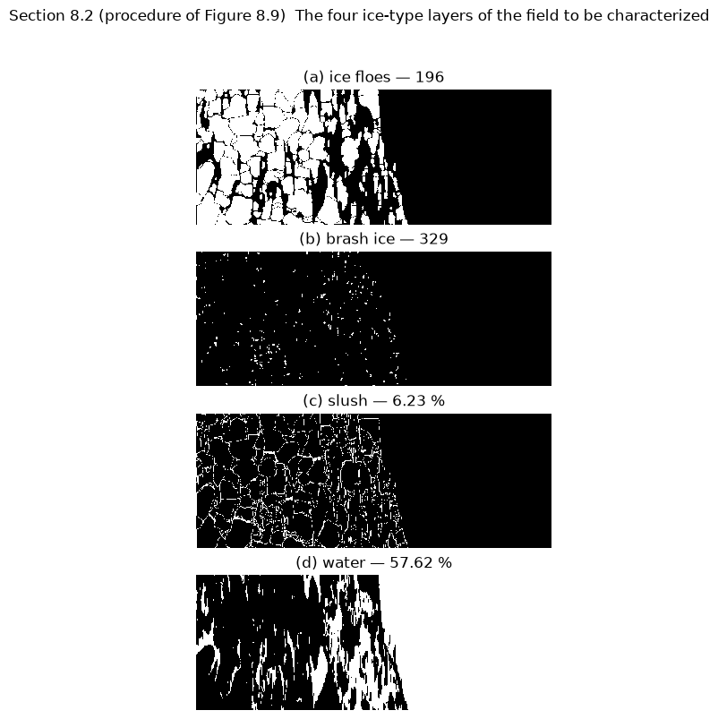

```python
RGB = I[::SCALE, ::SCALE]
print(f"Algorithms 3+4+5 on {RGB.shape[0]} x {RGB.shape[1]} px ('carried out directly', p. 182): "
      f"Num = {P['Num']} GVF iterations, iter = {P['iter']} snake iterations, kms0 = {P['kms0']} clusters ...")
t0 = time.time()
ENH = sea_ice_field(RGB, verbose=False)                 # = sea_ice_edge_detection -> ice_shape_enhancement
print(f"  {time.time() - t0:.1f} s")

COV = ENH.coverage.as_percent()
print(f"  {len(ENH.ice_floe)} ice floes, {len(ENH.brash_ice)} brash pieces"
      + book("498 ice floes, 201 brash pieces, p. 182 — NOT reproduced, open item O2"))
print(f"  coverage {COV['IceFloe']:.2f} % floe / {COV['BrashIce']:.2f} % brash / {COV['Slush']:.2f} % slush / "
      f"{COV['Water']:.2f} % water" + book("76.73 / 0.46 / 9.05 / 13.76 %, p. 182"))
print(f"  floe areas {int(min(f.Area for f in ENH.ice_floe))} .. "
      f"{int(max(f.Area for f in ENH.ice_floe))} px"
      + book("the Fig. 8.10 tick list implies the book's were 1 px .. [3484, 3503] px"))

fig, axes = plt.subplots(4, 1, figsize=(13, 9))
for ax, layer, t in ((axes[0], ENH.index_floe != 0, f"(a) ice floes — {len(ENH.ice_floe)}"),
                     (axes[1], ENH.index_brash != 0, f"(b) brash ice — {len(ENH.brash_ice)}"),
                     (axes[2], ENH.index_slush != 0, f"(c) slush — {COV['Slush']:.2f} %"),
                     (axes[3], ENH.index_water != 0, f"(d) water — {COV['Water']:.2f} %")):
    imshow_matlab(ax, T(layer), title=t)
fig.suptitle("Section 8.2 (procedure of Figure 8.9)  The four ice-type layers of the field to be characterized")
plt.show()
```

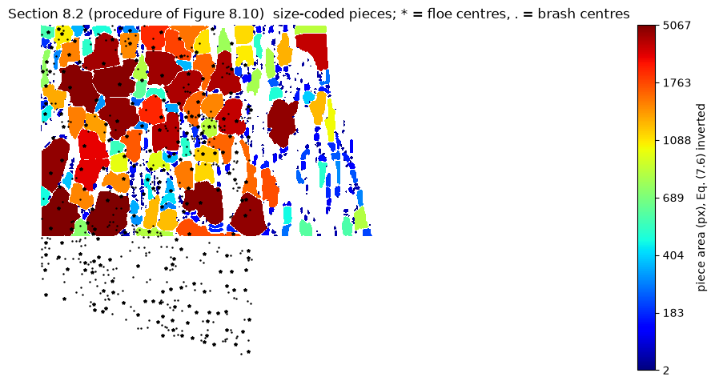

```
our colour-bar tick labels: [2, 183, 404, 689, 1088, 1763, 5067]
book Figure 8.10 (p. 186) : [1, 177, 391, 664, 1040, 1650, 3483]
  Those seven integers have a unique pre-image (C_min = 9, C_max in 9693..9698), which is how we know the book's smallest piece was 1 px and its largest ~3.5k px. Ours differ — open item O2, again.
```

```python
# Figure 8.10: every identified piece coloured by its size with ch07's Eq. (7.6),
#     Color(p) = C1 * (1 - exp(-area/C2)),   C1 = 10000, C2 = 1000,
# and the colour bar labelled with that equation INVERTED, -round(C2*ln(1 - c/C1)).
cmap = plt.get_cmap("jet").copy(); cmap.set_bad("white")
fig, ax = plt.subplots(figsize=(13, 5.6))
im = ax.imshow(T(np.ma.masked_where(ENH.index == 0, ENH.index)), cmap=cmap, interpolation="nearest")
if ENH.floe_cen.size:
    ax.plot(ENH.floe_cen[:, 0] - 1, ENH.floe_cen[:, 1] - 1, "k*", markersize=3)
if ENH.brash_cen.size:
    ax.plot(ENH.brash_cen[:, 0] - 1, ENH.brash_cen[:, 1] - 1, "k.", markersize=1.5)
ax.set_axis_off()
colours = np.concatenate([ENH.color_floe, ENH.color_brash])
size_colorbar(fig, im, colours, 6, ax=ax, label="piece area (px), Eq. (7.6) inverted")
ax.set_title("Section 8.2 (procedure of Figure 8.10)  size-coded pieces; * = floe centres, . = brash centres")
plt.show()

_, ticks = colorbar_area_ticks(colours, 6)
print(f"our colour-bar tick labels: {ticks.tolist()}")
print("book Figure 8.10 (p. 186) : [1, 177, 391, 664, 1040, 1650, 3483]")
print("  Those seven integers have a unique pre-image (C_min = 9, C_max in 9693..9698), which is how we know "
      "the book's smallest piece was 1 px and its largest ~3.5k px. Ours differ — open item O2, again.")
```

### 8.2.1 Sea ice numerical modeling (pp. 184–189) — replaces `sea_ice_model.m`

A discrete-element simulator cannot ingest a bitmap; it needs *objects*. So every identified piece is replaced by a simple geometric primitive: **each ice floe by its bounding minimum-area (convex) polygon** — in the code `convhull(x, y, 'simplify', true)` on the floe's own pixel coordinates — and **each brash piece by an area-equivalent disk**, $r_i = \sqrt{A_i/\pi}$, $p_i = 2\pi r_i$. Because a hull is bigger than the shape it wraps, "the polygonized floes … may overlap other floes and brash pieces", so each modelled piece also carries an **overlap flag**: the serial numbers of the floes and brash pieces whose boundary it crosses. A DEM simulator uses that list to resolve the initial interpenetration before the first time step (Fig. 8.16).

Three details of the shipped code matter more than the geometry:

- the areas, centres and perimeters come from `polygeom` (H. J. Sommer III), not from `regionprops` — the `regionprops` + `polyarea` alternative is in the file, commented out;
- floe–floe and floe–brash overlap is `polyxpoly`, a genuine polyline crossing test, but **brash–brash** is the pure circle test $\lVert c_i - c_j \rVert < r_i + r_j$;
- the crossing test is guarded by `if xx ~= NaN`, which does **not** mean what it looks like — see the *MATLAB traps* section below.

Parity: `Area`, `Center`, `Perimeter`, `Radius` and all four `Intersect` lists are **exact** against MATLAB and against the authors' own shipped structure (all 3992 overlap entries, as sets); only the hull's vertex *order* differs, so the contract is on the vertex **set** and on the rasterised mask.

[output not shown]

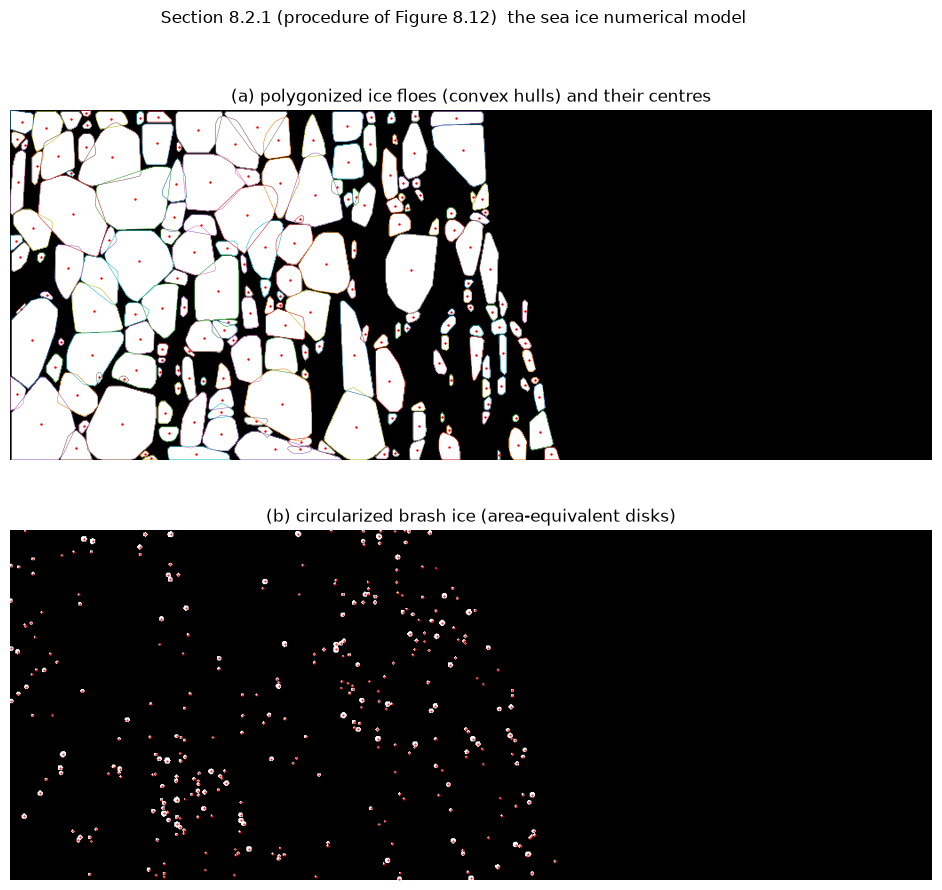

```python
t0 = time.time()
MODEL = sea_ice_model(ENH.ice_floe, ENH.brash_ice, ENH.index_floe)
print(f"sea_ice_model.m: {time.time() - t0:.1f} s for {len(MODEL.floe)} floes + {len(MODEL.brash)} brash pieces")
print(f"  crossing tests actually run: {MODEL.n_pairs_tested} of the M-file's {MODEL.n_pairs_total} "
      "(an axis-aligned bounding-box prefilter — provably inert: a common point of two polylines lies in BOTH "
      "bounding boxes, so disjoint boxes cannot cross)")

poly_area = np.array([f.Area for f in MODEL.floe])
raw_area = np.array([float(p.Area) for p in ENH.ice_floe])
print(f"  polygon areas {poly_area.min():.1f} .. {poly_area.max():.1f} px^2 "
      f"(pixel counts {raw_area.min():.0f} .. {raw_area.max():.0f})")
print(f"  p. 184 says 'the polygonized floes will not be smaller than the actual identified floes' — yet "
      f"{int((poly_area < raw_area).sum())} of {poly_area.size} continuous hull areas are SMALLER than the "
      "pixel count they enclose, because polygeom measures the hull through pixel CENTRES (erratum E6). "
      "The rasterised hull is still a superset, which is the claim that matters for a simulator.")
print(f"  brash radii {min(b.Radius for b in MODEL.brash):.3f} .. "
      f"{max(b.Radius for b in MODEL.brash):.3f} px")
print(f"  overlap flags: floe-floe {sum(f.Intersect.floe.size for f in MODEL.floe)}, "
      f"floe-brash {sum(f.Intersect.brash.size for f in MODEL.floe)}, "
      f"brash-brash {sum(b.Intersect.brash.size for b in MODEL.brash)}, "
      f"brash-floe {sum(b.Intersect.floe.size for b in MODEL.brash)}")

fig, axes = plt.subplots(2, 1, figsize=(14, 10))
axes[0].imshow(MODEL.bw_floe.T, cmap="gray", vmin=0, vmax=1)
for f in MODEL.floe:
    axes[0].plot(f.Vertices[:, 1] - 1, f.Vertices[:, 0] - 1, linewidth=0.4)
    axes[0].plot(f.Center[1] - 1, f.Center[0] - 1, "r+", markersize=2)
axes[0].set_axis_off(); axes[0].set_title("(a) polygonized ice floes (convex hulls) and their centres")
axes[1].imshow(MODEL.bw_brash.T, cmap="gray", vmin=0, vmax=1)
for b in MODEL.brash:
    axes[1].plot(b.Center[1] - 1, b.Center[0] - 1, "r.", markersize=1)
axes[1].set_axis_off(); axes[1].set_title("(b) circularized brash ice (area-equivalent disks)")
fig.suptitle("Section 8.2.1 (procedure of Figure 8.12)  the sea ice numerical model")
plt.show()
```

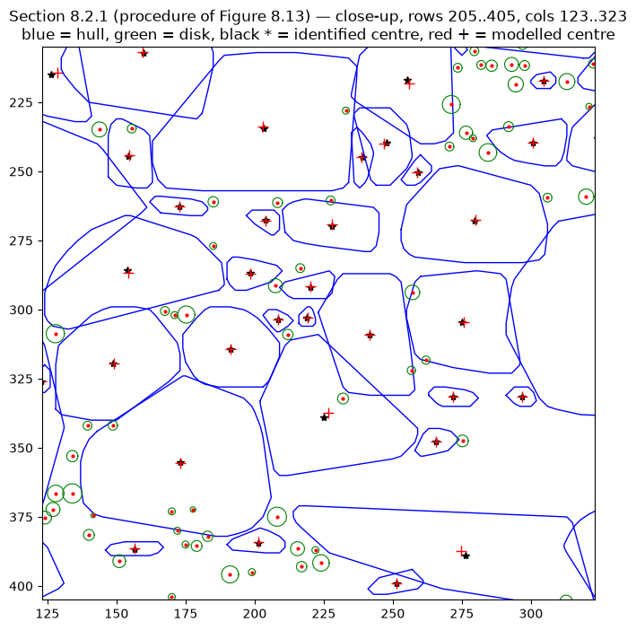

```
The identified centre and the modelled centre nearly coincide — the convex hull is a good area-preserving stand-in for a rounded MIZ floe, which is the assumption the whole section rests on.
```

```python
# Figure 8.13 — a close-up, so that the polygon boundaries and the two kinds of centre are visible.
# The book does not say which region it shows, so the densest 200x200 box is used and labelled as our choice.
H, W = ENH.index_floe.shape[:2]
cx = np.array([f.Center[0] for f in MODEL.floe]); cy = np.array([f.Center[1] for f in MODEL.floe])
w = min(200, W); h = min(200, H)
x0 = int(np.clip(np.median(cx) - w / 2, 0, max(W - w, 0)))
y0 = int(np.clip(np.median(cy) - h / 2, 0, max(H - h, 0)))
t_circ = np.linspace(0, 2 * np.pi, 60)

fig, ax = plt.subplots(figsize=(8, 8))
ax.set_xlim(x0, x0 + w); ax.set_ylim(y0 + h, y0); ax.set_aspect("equal")
for i, f in enumerate(MODEL.floe):
    if x0 - 50 <= f.Center[0] <= x0 + w + 50 and y0 - 50 <= f.Center[1] <= y0 + h + 50:
        ax.plot(f.Vertices[:, 0] - 1, f.Vertices[:, 1] - 1, "b-", linewidth=1)
        ax.plot(ENH.ice_floe[i].Center.ravel()[0] - 1, ENH.ice_floe[i].Center.ravel()[1] - 1, "k*", markersize=6)
        ax.plot(f.Center[0] - 1, f.Center[1] - 1, "r+", markersize=8)
for b in MODEL.brash:
    if x0 - 50 <= b.Center[0] <= x0 + w + 50 and y0 - 50 <= b.Center[1] <= y0 + h + 50:
        ax.plot(b.Center[0] - 1 + b.Radius * np.cos(t_circ), b.Center[1] - 1 + b.Radius * np.sin(t_circ),
                "g-", linewidth=0.8)
        ax.plot(b.Center[0] - 1, b.Center[1] - 1, "r.", markersize=4)
ax.set_title(f"Section 8.2.1 (procedure of Figure 8.13) — close-up, rows {y0}..{y0 + h}, cols {x0}..{x0 + w}\n"
             "blue = hull, green = disk, black * = identified centre, red + = modelled centre")
plt.show()
print("The identified centre and the modelled centre nearly coincide — the convex hull is a good area-preserving "
      "stand-in for a rounded MIZ floe, which is the assumption the whole section rests on.")
```

### The floe size distributions of Figs. 8.11, 8.14 and 8.15 — replaces `color_hist.m` and `color_hist_comparison.m`

Both files are the same 50-bin histogram over `min_x : inter : max_x` = `20 : 70 : 3500`, drawn with each bar jet-coloured by ch07's **Eq. (7.6)** applied to its own bin centre, and with the colour bar's ticks labelled by that equation *inverted*. Fig. 8.11 histograms the **identified** floes (pixel areas), Fig. 8.14 the **polygonized** floes (`sea_ice_model` areas), and Fig. 8.15 the difference — the "floe size distribution error due to the shape simplification".

Two things about those figures are worth knowing before you read any agreement as evidence:

- the nine printed tick labels **20, 149, 297, 471, 682, 950, 1317, 1902, 3487** are a function of the three literals `min_x = 20`, `max_x = 3500`, `nn = 8` **and of nothing else** — a single 1-pixel floe and 500 copies of a 3499-pixel floe give the identical list. Reproducing them proves nothing about the floes (that is why the verification report explicitly disqualifies them as parity evidence);
- those labels come from `color_hist.m`'s `max_x = 3500`, but the shipped `color_hist_comparison.m` sets `max_x = 6000`, which would print **20, 153, 307, 488, 710, 996, 1398, 2081, 5952**. The figure in the book was made with the *other* file's constant — erratum **E3**. The port keeps the shipped 6000 as the default and takes `max_x=3500` as an argument to reproduce the plate.

```
50 bins, centres 20 .. 3450 px; the bars are drawn at n + inter/2 = 55 .. 3485 (the M-file shifts them)
z sums to 196 = every floe: MATLAB's hist() takes bin CENTRES and its two outer bins are UNBOUNDED, so nothing falls off the ends (core.histogram.hist, not np.histogram)
tick labels: [20, 149, 297, 471, 682, 950, 1317, 1902, 3487]
book Figs. 8.11/8.14/8.15 (pp. 187-188): [20, 149, 297, 471, 682, 950, 1317, 1902, 3487] — the same, and that agreement is a property of three constants, not of the data.
```

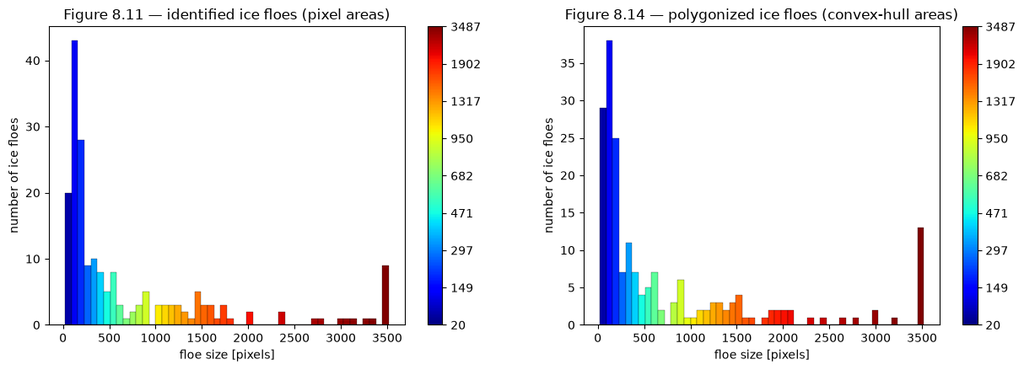

```python
def draw_color_hist(ax, ch, title, ylabel="number of ice floes"):
    """`color_hist.m` lines 18-33 redrawn: bar(n, z), each bar jet-coloured at Eq. (7.6) of its own centre.

    (The M-file colours the bars through an HG1 `FaceVertexCData` block that *errors* in MATLAB R2025a; the
    numbers behind it — `z`, `n`, `color`, `ysh`, `YT` — are reproduced exactly, and only the drawing differs.)
    """
    cmap = plt.get_cmap("jet")
    norm = plt.Normalize(ch.color_min, ch.color_max)
    ax.bar(ch.n, ch.z, width=ch.params["inter"], color=cmap(norm(ch.color)), edgecolor="k", linewidth=0.2)
    ax.set_xlabel("floe size [pixels]"); ax.set_ylabel(ylabel); ax.set_title(title)
    cb = ax.figure.colorbar(plt.cm.ScalarMappable(norm=norm, cmap=cmap), ax=ax)
    cb.set_ticks(ch.tick_values); cb.set_ticklabels([str(int(v)) for v in ch.tick_labels])
    return cb

CH_RAW  = color_hist(raw_area)                          # Figure 8.11 — the identified floes
CH_POLY = color_hist(poly_area)                         # Figure 8.14 — the polygonized floes
print(f"{CH_RAW.nbins} bins, centres {CH_RAW.centers[0]:g} .. {CH_RAW.centers[-1]:g} px; the bars are drawn at "
      f"n + inter/2 = {CH_RAW.n[0]:g} .. {CH_RAW.n[-1]:g} (the M-file shifts them)")
print(f"z sums to {int(CH_RAW.z.sum())} = every floe: MATLAB's hist() takes bin CENTRES and its two outer bins "
      "are UNBOUNDED, so nothing falls off the ends (core.histogram.hist, not np.histogram)")
print(f"tick labels: {CH_RAW.tick_labels.tolist()}")
print("book Figs. 8.11/8.14/8.15 (pp. 187-188): [20, 149, 297, 471, 682, 950, 1317, 1902, 3487] — the same, and "
      "that agreement is a property of three constants, not of the data.")

fig, axes = plt.subplots(1, 2, figsize=(15, 4.6))
draw_color_hist(axes[0], CH_RAW, "Figure 8.11 — identified ice floes (pixel areas)")
draw_color_hist(axes[1], CH_POLY, "Figure 8.14 — polygonized ice floes (convex-hull areas)")
plt.show()
```

[output not shown]

[figure not shown]

```python
# Figure 8.15 — the difference.  `color_hist_comparison.m` line 29 computes `z_d = z - z0` with
# z  = hist(polygonized areas)  (Fig. 8.14)  and  z0 = hist(identified areas)  (Fig. 8.11),
# i.e. POLYGONIZED minus IDENTIFIED.
CMP = color_hist_comparison(poly_area, raw_area, max_x=3500)      # max_x = 3500 reproduces the printed bar (E3)
print(f"z_d[:6] = {CMP.z_d[:6].astype(int).tolist()}, range {int(CMP.z_d.min())} .. {int(CMP.z_d.max())}, "
      f"sum {int(CMP.z_d.sum())} (= 0: polygonization moves floes between bins, it does not create them)")
print(f"first bin z_d[0] = {int(CMP.z_d[0]):+d}")
print("\nERRATUM E11 — the book states this subtraction the wrong way round. p. 188 reads 'by subtracting the "
      "histograms of Figure 8.12(a) from Figure 8.10', i.e. identified - polygonized; the code computes "
      "polygonized - identified. The PRINTED PLATE follows the code: its leftmost bar rises ABOVE the zero "
      "line, the same sign as our z_d[0] above. Fig. 8.15's own caption ('Error between the floe size "
      "distributions of Figure 8.11 and Figure 8.14') is order-neutral and correct.")
print("The code and the plate are the authority; the body sentence is the erratum. A global sign flip in the "
      "port would now be caught by the sign of the first bin, not merely by the shape of the bars.")

fig, ax = plt.subplots(figsize=(10, 4.6))
draw_color_hist(ax, CMP, "Figure 8.15 — floe size distribution error, $z - z_0$ (polygonized - identified)",
                ylabel="difference in number of ice floes")
ax.axhline(0, color="k", linewidth=0.8)
plt.show()
```

## 8.3 Sea ice floe size statistic (pp. 189–194)

This is the part of the chapter the reader can reproduce completely. During OATRC'15 a helicopter (AS-335NP off IB *Oden*) flew at about **1314 m** at 40 m/s with a gyro-stabilised **Red Dragon** camera (5568 × 3132, 25 fps, sampled at 0.1 Hz) and covered 3 × 3 nautical miles. One frame (Fig. 8.18) was processed by the Chapter 7 pipeline into **2888 ice floes and 3452 brash pieces**, covering 58.00 / 4.85 / 21.21 / 15.94 % — and that processed frame is the Appendix-B structure that ships with the book. Pixels become metres through a single literal, `length_over_Pixel = 1.1794` m/px, obtained from IB *Oden*'s known length in frames taken at an equivalent height (the book never prints the number; only the code has it).

Each floe is then sized by **Eq. (8.1)**, the "mean clipper diameter" (MCD):

$$L_i = \sqrt{\frac{4 A_i}{\pi}}$$

which is the diameter of the circle of the same area. Two remarks the book does not make: "clipper" is a typo for **caliper** (the standard term, Rothrock & Thorndike 1984), and Eq. (8.1) is not a caliper diameter at all — it is the **area-equivalent circle diameter**. The acronym is kept because the code, the folder and the figures all use it (erratum **E5**).

> **Without the shipped `.mat` files** the cells below run the identical chain on the field identified in §8.2 and say so on every figure. Nothing is faked: the book's own numbers are printed only when its own data is present.

```python
if HAVE_BOOK_MAT:
    ICE = load_iceimage_mat(MAT_ICEIMAGE)                    # main_WL_new.m line 7
    ICE_LABEL = "the authors' shipped section 8.3 structure"
else:
    # Graceful degradation: the same Appendix-B structure, built from OUR section 8.2 field (SeaIce_Image_Structure.m).
    ICE = sea_ice_image_structure(ENH.ice_floe, ENH.brash_ice, MODEL.floe, MODEL.brash, ENH.coverage,
                                  ENH.index_floe, ENH.index_residue)
    ICE_LABEL = "OUR section 8.2 field (SKIP: the book's section 8.3 .mat is absent)"
print(f"{ICE_LABEL}\n  {ICE.summary()}")
print(f"  Field: NumFloes = {ICE.Field.NumFloes}, NumBrash = {ICE.Field.NumBrash}"
      + mcd_book("2888 floes, 3452 brash pieces, p. 190"))
cov = [ICE.Field.CovFloes, ICE.Field.CovBrash, ICE.Field.CovSlush, ICE.Field.CovWater]
print("  coverage " + " / ".join(f"{100 * c:.5f}" for c in cov) + " %"
      + mcd_book("58.00 / 4.85 / 21.21 / 15.94 %, p. 190"))
if HAVE_BOOK_MAT:
    print("  ERRATUM E4: the water figure is TRUNCATED, not rounded — 15.945957 % is printed as 15.94 %, "
          "where correct rounding gives 15.95 %. The other three are the same either way.")

# Eq. (8.1), on the pixel areas (main_WL_new.m lines 30-31).
areas_px = np.array([f.Area for f in ICE.Floe], dtype=float)
mcd = mean_caliper_diameter(areas_px, LENGTH_OVER_PIXEL)
print(f"\nEq. (8.1)  L = sqrt(4A/pi):  {mcd.size} floes, MCD {mcd.min():.4f} .. {mcd.max():.4f} m, "
      f"mean {mcd.mean():.4f} m" + mcd_book("Fig. 8.21 spans 10^0.8 .. 10^2.1 m"))
print(f"  check by inverting it: pi*(L/2)^2 / lop^2 - A = {np.abs(np.pi * (mcd / 2) ** 2 / LENGTH_OVER_PIXEL ** 2 - areas_px).max():.3e} px^2")
```

```
OUR section 8.2 field (SKIP: the book's section 8.3 .mat is absent)
  IceImage: 394x1038 px, 196 floes, 329 brash pieces, FSD 51 intervals
  Field: NumFloes = 196, NumBrash = 329
  coverage 35.04152 / 1.10937 / 6.23343 / 57.61568 %

Eq. (8.1)  L = sqrt(4A/pi):  196 floes, MCD 8.7267 .. 95.0296 m, mean 29.2814 m
  check by inverting it: pi*(L/2)^2 / lop^2 - A = 9.095e-13 px^2
```

```python
# `main_WL_new.m` in one call: Eq. (8.1) on the polygon areas AND on the pixel areas, then
# plot_color_bar_and_floe for each.  The second call is Figure 8.19 and its histogram is Figure 8.20.
t0 = time.time()
R = mcd_analysis(ICE, length_over_pixel=LENGTH_OVER_PIXEL, color_limit_n=COLOR_LIMIT_N)
print(f"main_WL_new.m: {time.time() - t0:.2f} s")
print(f"  Raw  (pixel areas -> Figs. 8.19/8.20): branch = {R.raw.kind}, hist(MCD, 1:100) sums to "
      f"{int(R.raw.counts.sum())}, peak {int(R.raw.counts.max())} at {R.raw.centers[int(R.raw.counts.argmax())]:g} m"
      + mcd_book("Fig. 8.20 axes stop at N = 450, so the 454-floe peak at 7 m is clipped by the plate"))
print(f"  Poly (polygon areas, computed but never printed in the book): branch = {R.poly.kind}, peak "
      f"{int(R.poly.counts.max())} at {R.poly.centers[int(R.poly.counts.argmax())]:g} m")
print(f"  colour index = the NEAREST histogram centre (not the hist bin): {R.raw.color_index.min()}"
      f"..{R.raw.color_index.max()}, of which {int((R.raw.color_index > COLOR_LIMIT_N).sum())} floes are clamped "
      f"to the {COLOR_LIMIT_N}th colour — that is what the book's '>=30 [m]' top tick means")
print(f"  rgbImage: {R.raw.rgb_image.shape}  (MATLAB never pre-allocates it — see the MATLAB traps below)")

if MAT_MCD is not None:
    import scipy.io as sio
    gold = np.asarray(sio.loadmat(MAT_MCD)["Raw_MCD"], dtype=float).ravel()
    print(f"\n  vs the authors' own saved Raw_MCD in MCD_results.mat ({gold.size} values): "
          f"max |delta| = {np.abs(gold - R.raw_mcd).max():.1f}")
    print("  That 0.0 is the strongest single piece of evidence in this chapter: the port reproduces the "
          "authors' own published intermediate result bit for bit, without ever seeing their code run.")
```

```
main_WL_new.m: 0.11 s
  Raw  (pixel areas -> Figs. 8.19/8.20): branch = Pixels, hist(MCD, 1:100) sums to 196, peak 19 at 10 m
  Poly (polygon areas, computed but never printed in the book): branch = Vertices, peak 15 at 9 m
  colour index = the NEAREST histogram centre (not the hist bin): 9..95, of which 66 floes are clamped to the 30th colour — that is what the book's '>=30 [m]' top tick means
  rgbImage: (619, 394, 3)  (MATLAB never pre-allocates it — see the MATLAB traps below)
```

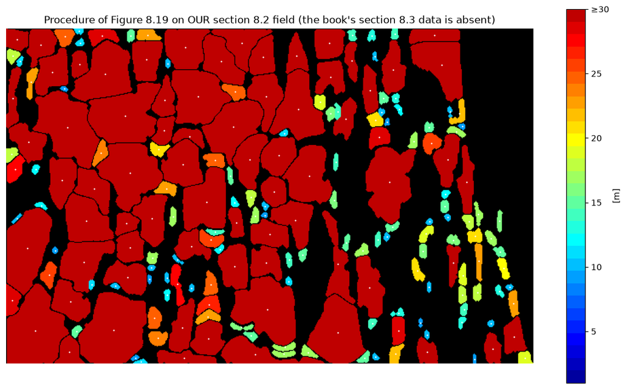

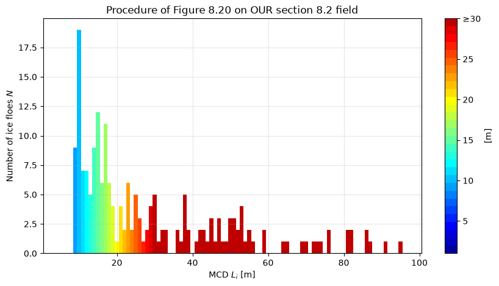

```
non-zero bins: centres [9, 10, 11, 12, 13, 14, 15, 16] ... [87, 91, 95] m
colour bar: caxis = [1, 30] -> MATLAB's default ticks 5, 10, 15, 20, 25, 30, printed in the book as '5 10 15 20 25 >=30 [m]'
```

```python
# Figure 8.19 — every floe painted in the jet colour of its MCD, with a white dot at its centre.
IMG19 = R.raw.rgb_image if HAVE_BOOK_MAT else T(R.raw.rgb_image)
dot_x = R.raw.centres_xy[:, 0] - 1 if HAVE_BOOK_MAT else R.raw.centres_xy[:, 1] - 1
dot_y = R.raw.centres_xy[:, 1] - 1 if HAVE_BOOK_MAT else R.raw.centres_xy[:, 0] - 1

fig, ax = plt.subplots(figsize=(14, 8))
ax.imshow(IMG19)
ax.plot(dot_x, dot_y, "w.", markersize=1.5)
ax.set_axis_off()
mcd_colorbar(fig, ax, R.raw.color_m, (R.raw.centers[0], R.raw.centers[COLOR_LIMIT_N - 1]))
ax.set_title(("Figure 8.19 — ice floes coloured by MCD (white dots = floe centres)" if HAVE_BOOK_MAT else
              "Procedure of Figure 8.19 on OUR section 8.2 field (the book's section 8.3 data is absent)"))
plt.show()

# Figure 8.20 — the MCD histogram, bar i coloured color_M(min(i, 30), :).
idx = np.minimum(np.arange(1, R.raw.centers.size + 1), COLOR_LIMIT_N) - 1
fig, ax = plt.subplots(figsize=(10, 5))
ax.bar(R.raw.centers, R.raw.counts, width=1.0, color=R.raw.color_m[idx], edgecolor="none")
ax.set_xlabel("MCD $L_i$ [m]"); ax.set_ylabel("Number of ice floes $N$"); ax.grid(alpha=0.3); ax.margins(x=0)
mcd_colorbar(fig, ax, R.raw.color_m, (R.raw.centers[0], R.raw.centers[COLOR_LIMIT_N - 1]))
ax.set_title(("Figure 8.20 — MCD histogram of the floes of Figure 8.19" if HAVE_BOOK_MAT else
              "Procedure of Figure 8.20 on OUR section 8.2 field"))
plt.show()
nz = np.flatnonzero(R.raw.counts)
print(f"non-zero bins: centres {R.raw.centers[nz][:8].astype(int).tolist()} ... "
      f"{R.raw.centers[nz][-3:].astype(int).tolist()} m"
      + mcd_book("6..58 m plus two isolated bars at 76 and 84 m"))
print(f"colour bar: caxis = [{R.raw.centers[0]:g}, {R.raw.centers[COLOR_LIMIT_N - 1]:g}] -> MATLAB's default "
      "ticks 5, 10, 15, 20, 25, 30, printed in the book as '5 10 15 20 25 >=30 [m]'")
```